*Practical Machine Learning/ Prediction Assignment*  
**Boriana Valentinova**  
**22 de diciembre de 2015**

**Introduction**

Human activity recognition research has traditionally focused on discriminating between different activities. However, the “how (well)” investigation has only received little attention so far, even though it potentially provides useful information for a large variety of applications, such as sports training (http://groupware.les.inf.puc-rio.br/har).

For the prediction of how well individuals performed the assigned exercise, six young healthy participants were asked to perform one set of 10 repetitions of the Unilateral Dumbbell Biceps Curl in five different fashions: exactly according to the specification (Class A), throwing the elbows to the front (Class B), lifting the dumbbell only halfway (Class C), lowering the dumbbell only halfway (Class D) and throwing the hips to the front (Class E).

This report aims to use machine learning algorithms to predict the manner in which they did the exercise. The dependent variable or response is the “classe” variable in the training set.

*Data*

**Loading data:**

```r
#setwd("C:/Documentos Boriana/Practical Machine Learning")
training<- read.csv("pml-training.csv", na.strings=c("", "NA", "NULL"))
testing<- read.csv("pml-testing.csv", na.strings=c("", "NA", "NULL"))
dim(training)
```

```
## [1] 19622   160
```

```r
dim(testing)
```

```
## [1]  20 160
```

**Processing data:**

Training data was partitioned and preprocessed using the code described below. All variables with at least one “NA” were excluded from the analysis. Variables related to time and user information were excluded for a total of 51 variables and 19622 class measurements. Same variables were maintained in the test data set (Validation dataset) to be used for predicting the 20 test cases provided.

```r
## NA exclusion for all available variables
training.na <- training[ , colSums(is.na(training)) == 0]
dim(training.na)
```

```
## [1] 19622    60
```

```r
## Variables with user information, time and undefined
training.clean<-training.na[,-c(1:8)]
dim(training.clean)
```

```
## [1] 19622    52
```

```r
## 20 test cases provided clean info - Validation data set
allcleantest<-testing[,names(training.clean[,-52])]
dim(allcleantest)
```

```
## [1] 20 51
```

```r
library(tree)
set.seed(12345)
tree.training=tree(classe~.,data=training.clean)
summary(tree.training)
```

```
##
## Classification tree:
## tree(formula = classe ~ ., data = training.clean)
## Variables actually used in tree construction:
##  [1] "pitch_forearm"     "magnet_belt_y"     "accel_forearm_z"
##  [4] "magnet_dumbbell_y" "roll_forearm"      "magnet_dumbbell_z"
##  [7] "pitch_belt"        "yaw_belt"          "accel_forearm_x"
## [10] "accel_dumbbell_z"  "magnet_forearm_y"  "magnet_arm_x"
## [13] "gyros_belt_z"
## Number of terminal nodes:  20
## Residual mean deviance:  1.695 = 33220 / 19600
## Misclassification error rate: 0.3322 = 6519 / 19622
```

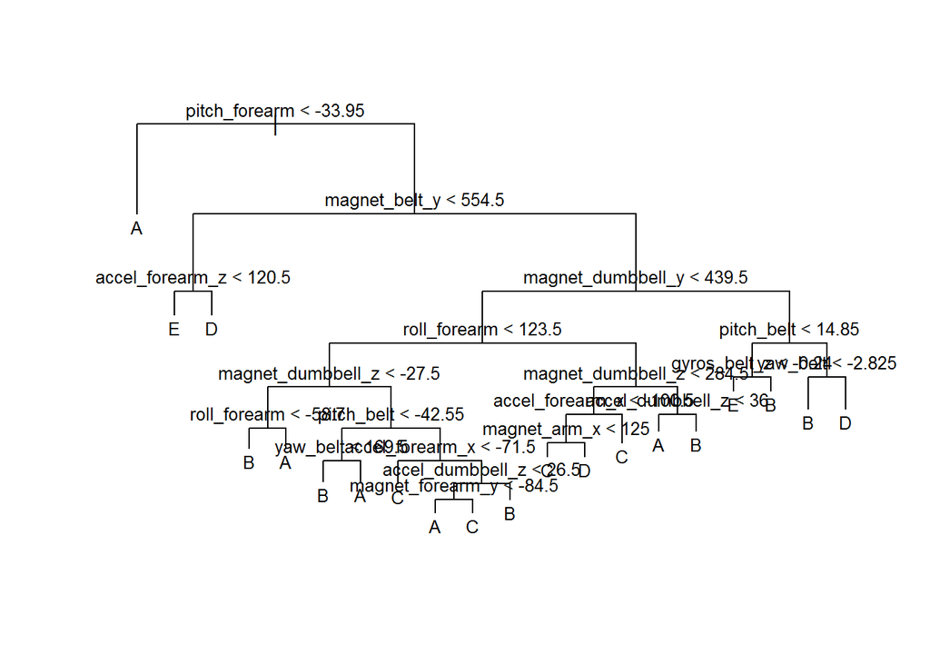

```r
plot(tree.training)
text(tree.training,pretty=0, cex =.8)
```

In continuation, the tidy dataset was subset in order to generate a test set independent from the 20 cases provided. Partitioning was performed to obtain a 75% training set and a 25% test set.

```r
#Data cleaning
library(caret)
inTrain<-createDataPartition(y=training.clean$classe, p=0.75,list=F)
train<-training.clean[inTrain,]
test<-training.clean[-inTrain,]
#Training and test set dimensions
dim(train)
```

```
## [1] 14718    52
```

```r
dim(test)
```

```
## [1] 4904   52
```

*Analysis and Conclusions*

Random forest trees were generated for the training dataset using cross-validation. Then the generated algorithm was scrutinized under the partitioned training set to test the accuracy and estimate error of prediction.

```r
library(caret)
set.seed(13335)
fitControl<-trainControl(method="cv", number=5, allowParallel=T, verbose=T)
fit<-train(classe~.,data=train, method="rf", trControl=fitControl, verbose=F)
predrf<-predict(fit, newdata=test)
confusionMatrix(predrf, test$classe)
```

```
## Confusion Matrix and Statistics
##
##           Reference
## Prediction    A    B    C    D    E
##          A 1395   12    0    0    0
##          B    0  933    3    0    0
##          C    0    3  849    5    1
##          D    0    0    3  799    1
##          E    0    1    0    0  899
##
## Overall Statistics
##
##                Accuracy : 0.9941
##                  95% CI : (0.9915, 0.996)
##     No Information Rate : 0.2845
##     P-Value [Acc > NIR] : < 2.2e-16
##
##                   Kappa : 0.9925
##  Mcnemar's Test P-Value : NA
##
## Statistics by Class:
##
##                      Class: A Class: B Class: C Class: D Class: E
## Sensitivity            1.0000   0.9831   0.9930   0.9938   0.9978
## Specificity            0.9966   0.9992   0.9978   0.9990   0.9998
## Pos Pred Value         0.9915   0.9968   0.9895   0.9950   0.9989
## Neg Pred Value         1.0000   0.9960   0.9985   0.9988   0.9995
## Prevalence             0.2845   0.1935   0.1743   0.1639   0.1837
## Detection Rate         0.2845   0.1903   0.1731   0.1629   0.1833
## Detection Prevalence   0.2869   0.1909   0.1750   0.1637   0.1835
## Balanced Accuracy      0.9983   0.9912   0.9954   0.9964   0.9988
```

```r
pred20<-predict(fit, newdata=allcleantest)
# Output for the prediction of the 20 cases provided
pred20
```

```
##  [1] B A B A A E D B A A B C B A E E A B B B
## Levels: A B C D E
```

Manner of performing exercises: exactly according to the specification (Class A), throwing the elbows to the front (Class B), lifting the dumbbell only halfway (Class C), lowering the dumbbell only halfway (Class D) and throwing the hips to the front (Class E).

**Code to automatically create the files and copy in your current working directory**

Please change the directory using setwd() command in case if you want to change the working directory where files should be saved.

```r
getwd()
```

```
## [1] "C:/Documentos Boriana/Practical Machine Learning"
```

```r
pml_write_files = function(x){
  n = length(x)
  for(i in 1:n){
    filename = paste0("problem_id_",i,".txt")
    write.table(x[i],file=filename,quote=FALSE,row.names=FALSE,col.names=FALSE)
  }
}
pml_write_files(pred20)
```